# AHRI Call Dashboard Project

Turning inbound & outbound call records into a Power BI dashboard

Sammi & Aji

ETC5543 Business Analytics Creative Activity

Australian HR Institute (AHRI)

## Background

The **Australian HR Institute (AHRI)** supports HR professionals through membership, certification, training and events.

### How incoming calls reach AHRI

```
flowchart LR
    C["`**External caller**`"] -->|"Main number"| M["`**Main IVR**
Automated menu`"]

    M -->|"Service selection"| Q["`**Team queue**
Routes calls to staff`"]

    Q -->|"Call offered"| S["`**Staff phone**`"]

    C -.->|"Direct staff number"| S

    classDef main fill:#006DAE,stroke:#006DAE,color:#ffffff,font-size:22px;
    classDef light fill:#E6F0F7,stroke:#006DAE,color:#004B7A,font-size:22px;

    class M main;
    class C,Q,S light;

    linkStyle 0,1,2 stroke:#006DAE,stroke-width:2px;
    linkStyle 3 stroke:#7F8C97,stroke-width:2px;
```

**The reporting gap:** email and online forms had CRM reporting. Phone activity was available mainly as raw Excel exports.

Illustrative routes: not every Main IVR call reaches a queue or a staff member. Our inbound analysis focuses on the main menu; outbound activity is analysed separately.

## Business problem

AHRI has no visibility and needs a clearer way to understand of

- **When** do members call?
- **Where** do their calls go?
- **How** do calls end, and how long do they take?
- **Who** is calling members back, and when?

**Our goal**

Turn the Teams phone exports into a Power BI dashboard that shows AHRI what’s happening on the phones.

**In scope:** inbound and outbound activity across the period of the export.  
**Out of scope:** live reporting and individual staff performance.

## Business questions

|  | Question | Dashboard page |
| --- | --- | --- |
| Inbound | How many calls arrive, and when? | Inbound Call Overview |
| Inbound | Where do callers go? | Routing and queue destinations |
| Inbound | How do calls end, and how long do they take? | Outcome and Duration |
| Outbound | Who is making outbound calls, and when? | Outbound activity |
| Outbound | How do outbound calls end, and how long do they last? | Outbound outcome and duration |

## Data and analysis scope

Both exports cover **6 April to 1 September 2026**.

**Inbound:** one call can create several system records.

```
flowchart LR
    R["`**9,859**
Inbound records`"] -->|"Group by shared ID"| G["`**6,361**
Linked call groups`"]

    G -->|"Include"| I["`**3,986**
With Main IVR`"]

    G -->|"Exclude"| D["`**2,375**
Without Main IVR`"]

    classDef source fill:#E6F0F7,stroke:#006DAE,color:#004B7A,font-size:24px;
    classDef group fill:#004B7A,stroke:#004B7A,color:#ffffff,font-size:24px;
    classDef included fill:#006DAE,stroke:#006DAE,color:#ffffff,font-size:24px;
    classDef excluded fill:#F1F3F5,stroke:#AAB3BA,color:#5F6B73,font-size:24px;

    class R source;
    class G group;
    class I included;
    class D excluded;

    linkStyle 0,1 stroke:#006DAE,stroke-width:2px;
    linkStyle 2 stroke:#7F8C97,stroke-width:2px;
```

Vanessa confirmed that calls without Main IVR are mostly direct to staff. We retain the 3,986 Main IVR groups and their related records. Groups do not represent unique people.

**Outbound scope:** 6,046 attempts by 18 approved staff across Membership, HRSC and Events.

## IDA and EDA: checking and exploring the data

### IDA · Check and prepare

Initial data analysis · Power Query

- **Inbound quality:** 334 missing account names and 785 missing start/end timestamps. Retained the rows with unknown values.
- **Scope:** grouped inbound rows by shared ID, selected Main IVR groups and filtered outbound to 18 approved staff.
- **Consistency:** cleaned account labels, set data types and converted UTC timestamps to Melbourne time.

### EDA · Explore patterns

Exploratory data analysis · Power BI and DAX

- **Timing:** compared daily, weekday, hourly and monthly activity, including a 7-day trailing average.
- **Routing and teams:** compared queue/overflow destinations and outbound volumes across teams.
- **Outcomes and duration:** examined technical statuses and duration bands. Compared mean and median to assess the effect of long calls.

Weekday averages include zero-activity days and exclude boundary dates. Full-month comparisons cover May–August.

# Inbound Results

## Inbound calls peak during business hours, with Tuesday the busiest day

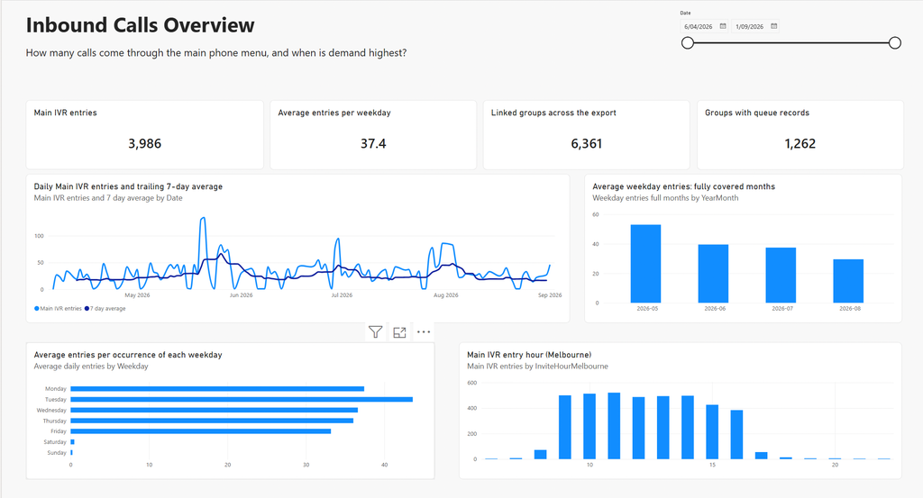

Page 1 · Inbound calls overview

- **Call volume:** 3,986 entries, averaging 37.4 per weekday.
- **Peak hours:** Most calls occur between 9 AM and 4 PM, declining after 5 PM.
- **Busiest day:** Tuesday (~44 entries), compared with Friday (~33).
- **Monthly trend:** Average weekday demand declined from ~53 in May to ~30 in August.

**For AHRI:** The dashboard identifies peak calling periods and demand patterns that can support staffing and phone coverage planning.

## Overflow use varies widely between services

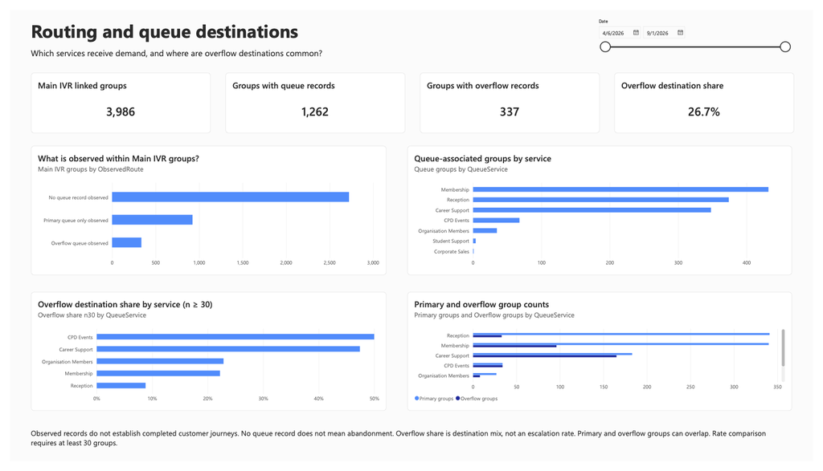

- **Top demand:** Membership, Reception, Career Support get the most calls
- **Overflow:** about 1 in 4 queued calls
- **High overflow share:** Career Support (~47%), CPD Events (~50%)

**For AHRI:** The dashboard shows where calls are routed, to support routing and resourcing reviews.

## Most calls end normally, but dropped calls are the longest

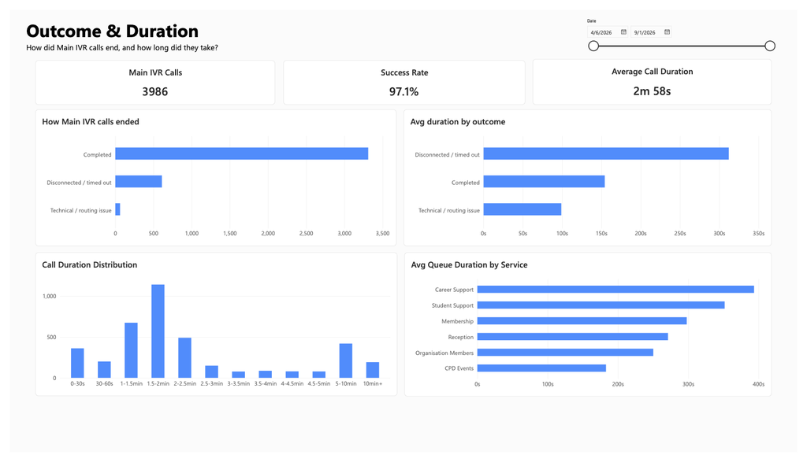

- **Call outcome:** 97.1% success rate
- **Dropped calls:** disconnected or timed-out calls lasted longest (~5 min)
- **Longest in queue:** Career Support (~6.5 min on average)

**For AHRI:** The dashboard shows where calls spend longest in the queue. *A completed call doesn’t mean the enquiry was resolved.*

# Outbound results

## The Membership team makes almost 9 in 10 outbound calls

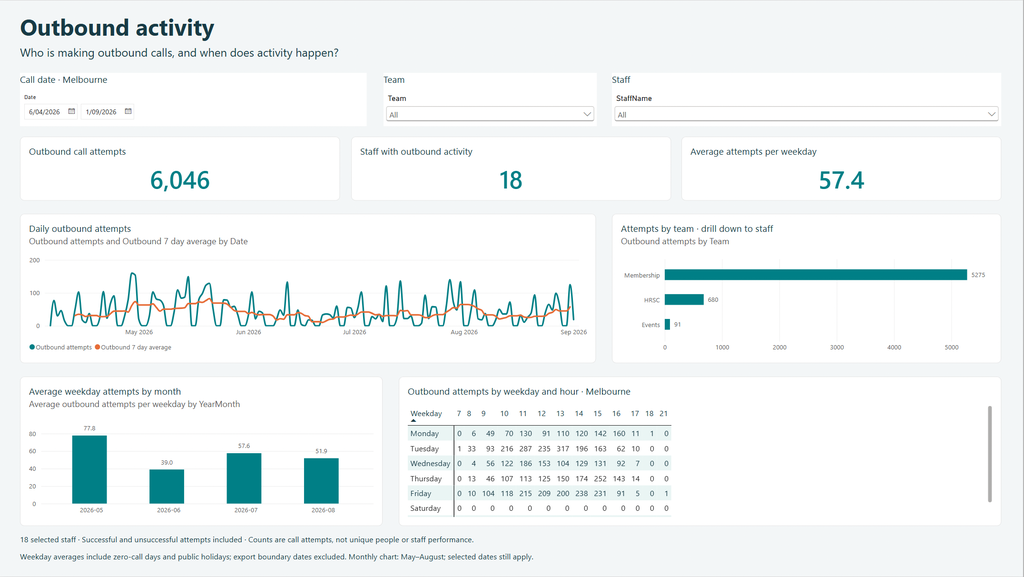

- **By team:** Membership 5,275 (~87%), HRSC 680, Events 91
- **By month:** peaked in May (77.8/weekday), dipped in June (39.0)
- **Busiest time:** Tuesday, 11am–2pm

**For AHRI:** shows outbound workload by team and over time. *Counts are call attempts, not staff performance.*

## 91% of outbound calls connect, most last under a minute

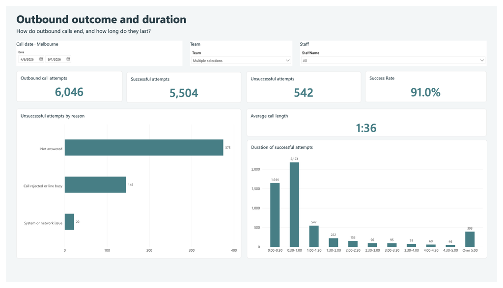

- **Connected:** 5,504 of 6,046 attempts (91%)
- **Main failure:** not answered (375 of 542)
- **Short calls:** 69% of connected calls last under 1 min (average 1:36)

**For AHRI:** shows how outbound calls end. *Connected may include voicemail; the data can’t tell.*

## Project achievements & limitations

### Key achievements

- **Call Visibility:** 3,986 inbound calls + 6,046 outbound attempts in the dashboard
- **Business insights:** 5 business questions, one dashboard page each
- **Repeatable process:** Power Query steps re-apply to future exports
- **Interactive analysis:** filter by date, team and staff

### Current limitations

- **Inbound:** no data on whether calls were resolved
- **Outbound:** no data on whether a person or voicemail answered, or why the call was made
- **Data constraints:** limited to what Microsoft Teams exports

**Next step:** add answer status, abandonment and call reason to the data, to measure **service quality** alongside call activity.